# COVID-19 Symptoms vs Confirmation (MS Cohort)

Are pwMS on DMTs more likely to be suspected/confirmed with COVID-19?

2025-11-01

[figure not shown]

[figure not shown]

[figure not shown]

# 1 Abstract

## 1.1 Background

People with multiple sclerosis (pwMS) frequently use disease-modifying therapies (DMTs), raising questions about COVID-19 risk.

## 1.2 Objective

Does current DMT use increase the risk of being diagnosed (suspected/confirmed) with COVID-19 among pwMS?

## 1.3 Methods

Cross-sectional analysis of the **Global Data Sharing Initiative (GDSI)** open dataset.  
- **Primary outcome:** suspected/confirmed COVID-19.  
- **Exposure:** current DMT (On vs Not on).  
- **Covariates:** sex, age group, comorbidities.  
- **Model:** logistic regression estimating adjusted odds ratios (AORs).  
- **Tools:** R (tidyverse, gtsummary, knitr, broom, DT).

## 1.5 Conclusion

In this cohort, **DMT use was not associated** with higher COVID-19 diagnosis risk. Conclusions on severity are limited by the small number of severe events.

# 2 Introduction

## 2.1 Literature Review

People with multiple sclerosis (MS) often take medicines called disease-modifying therapies (DMTs). These drugs change how the immune system works to reduce relapses, but this also made doctors worry that they might affect a person’s chances of getting COVID-19 or having a worse infection. Early studies from large MS registries found that most DMTs did not make people more likely to catch COVID-19. However, a few drugs —especially ocrelizumab and rituximab—were linked to more serious illness (Sormani et al., 2021)[1]. Later reviews showed the same pattern, while medicines like interferon-β, glatiramer acetate, and dimethyl fumarate appeared safe (Moghadasi et al., 2023)[2].

Other research found that people on DMTs were about as likely to get infected as those not on treatment once factors like age and other health conditions were considered (Salter et al., 2021 [3]; Garcia-Domínguez et al., 2024) [4] .

Overall, the evidence suggests that while a few treatments may lead to more severe COVID-19, being on a DMT generally does not increase the risk of infection.

## 2.2 Rationale for the present study

Current research on multiple sclerosis (MS) and COVID-19 mainly focuses on how severe the infection becomes for people taking disease-modifying therapies (DMTs), such as the risk of hospitalisation or intensive care. Much less is known about whether being on a DMT actually changes the likelihood of catching COVID-19 in the first place. This is an important gap because a therapy could influence infection risk differently from how it affects illness severity.

This study aims to explore that question by using the Global Data Sharing Initiative (GDSI) open dataset, which contains de-identified records of people with MS. The analysis treats COVID-19 diagnosis as a binary outcome that combines both suspected and confirmed infections, capturing real-world conditions when testing was limited and many cases went unconfirmed. It compares people currently on any DMT with those not receiving treatment to assess whether DMT exposure in general affects the odds of infection. By applying transparent, reproducible statistical methods in R and adjusting for age, sex, and comorbidities, the study provides a clear, openly verifiable estimate of COVID-19 infection risk among people with MS—adding to what is known about disease severity to give a fuller picture of DMT safety during the pandemic.

### 2.2.1 Analytical rationale

Logistic regression was chosen because the outcome variable—COVID-19 diagnosis—was binary (infected vs not infected), and the goal was to estimate the adjusted odds of infection associated with DMT exposure. Sex, age group, and comorbidity status were included as covariates to account for demographic and clinical factors known to influence infection risk in people with MS. The model assumes independence of observations and a logit-linear relationship between the predictors and the outcome; these assumptions were judged reasonable for this cohort. The analysis focused on effect size (odds ratios with 95% confidence intervals) rather than statistical significance alone. Given the small number of confirmed cases, suspected and confirmed infections were combined into a single binary outcome (infected = 1, not infected = 0). This approach preserved statistical power and better reflected the diagnostic uncertainty that characterized the early phases of the COVID-19 pandemic, when limited testing capacity and evolving case definitions led to substantial under-ascertainment of true infections. Surveillance analyses from this period indicate that confirmed case counts captured only a fraction of symptomatic infections worldwide, with many probable or suspected cases lacking laboratory confirmation despite compatible clinical presentation (Russell et al., 2020) [5]. Combining these categories therefore provides a more realistic representation of infection burden while maintaining analytical robustness given the available data.

## 2.3 Global Data Sharing Initiative dataset

**Overview.** The cohort was predominantly female and mainly within the 18–50 year age group, consistent with **Walton et al.** [6], which reports that females are approximately twice as likely to live with MS and that the mean age at diagnosis is ~32 years.  
**Data governance.** This dataset is openly available through the University of Cambridge PACE Department [7] under open-data sharing terms and contains de-identified participant records; no additional ethical approval was required for secondary analysis.

## 2.4 Data Variables Used in the Analysis

### 2.4.2 Variable used

sex: The biological sex of the patient. “Male” (20.77%) for males and “Female” (79.22%) for females. Possible missing values are 0.00%.

current_dmt: Indicates the status of the disease-modifying therapy (DMT) at the time of data entry of the patient. There are three unique values in the variable: “yes” (77.12%), “no” (8.85%) and “never_treated” (14.02%). 0.00% possible missing values. The values are measured as follows:F • yes: if the person is currently on a DMT • no: if the person is not currently on a DMT • never_treated: if the person has never been on a DMT

has_comorbidities: Indicates whether the person has any comorbidities. “Yes” (28.74%) indicates that there are comorbidities, and “No” (71.25%) indicates otherwise. Possible missing values are 0.00%.

age_in_cat: Indicates age in categories. Missing values for this field: 0.00%. 0: if the age range is between 0 and <18. 1: if the age range is between 18 and ≤50. 2: if the age range is between 51 and ≤70. 3: if the age range is 71 or greater.

covid19_diagnosis: It shows the perceived COVID-19 diagnosis of the patient. It has three unique values: “not_suspected” (75.19%), “suspected” (19.54%) and “confirmed” (5.25%). 0.00% missing values.

covid19_confirmed_case: Confirmed COVID-19 diagnosis of the patient. Has two unique values: “Yes” (5.25%) if the diagnosis is positive and “No” (94.74%) if it’s otherwise. 0.00% missing values.

covid19_has_symptoms: Indicates the presence or absence of COVID-19 symptoms. Has two unique values: “Yes” (31.77%) if there are one or more symptoms associated with COVID-19, such as fever, dry cough, fatigue, pain, sore throat, shortness of breath, nasal congestion, loss of taste or smell and pneumonia. “No” (68.22%) if there are no symptoms. 0.71% possible missing values.

### 2.4.3 Quality checks

After recoding, integrity checks were performed to confirm valid levels and identify any missing values:

```r
table(covid_ms$sex, useNA = "ifany")
table(covid_ms$dmt_status, useNA = "ifany")
table(covid_ms$age_group, useNA = "ifany")
```

```
##
## female   male
##    904    237
```

```
##
## Not on DMT     On DMT
##        261        880
```

```
##
##   <18 18-50 51-70   71+
##     0   883   258     0
```

# 3 Descriptive and inferential findings:

A summary of cohort characteristics by sex is shown in Table 1. Most participants were female (79%) and aged 18–50 years.

To simplify the three-level variable `covid19_diagnosis` (not suspected, suspected, confirmed) for analysis, a binary variable `infected` was created, coded as 1 for suspected/confirmed cases and 0 otherwise. This approach increased statistical power and captured the broader experience of COVID-19 within the cohort.

Overall, 283 participants (24.8%) had a suspected or confirmed infection, while 858 (75.2%) had no infection recorded. Infection rates were similar among those currently on DMT (24.5%) and those not on therapy (25.7%), indicating no meaningful association between DMT status and COVID-19 diagnosis. These findings were consistent with results from the subsequent logistic-regression model.

*Table 1. Distribution of cohort characteristics by sex (n = 1,141). The cohort was predominantly female and aged 18–50 years, with most participants currently receiving a disease-modifying therapy (DMT).*

**Distribution of Characteristics by Sex**

| **Characteristic** | **N** | **Sex** **female** N = 904<sup>1</sup> | **Sex** **male** N = 237<sup>1</sup> |
| --- | --- | --- | --- |
| age_group | 1,141 |  |  |
| <18 |  | 0 (0%) | 0 (0%) |
| 18-50 |  | 706 (78%) | 177 (75%) |
| 51-70 |  | 198 (22%) | 60 (25%) |
| 71+ |  | 0 (0%) | 0 (0%) |
| current_dmt | 1,141 |  |  |
| never_treated |  | 132 (15%) | 28 (12%) |
| no |  | 76 (8.4%) | 25 (11%) |
| yes |  | 696 (77%) | 184 (78%) |
| has_comorbidities | 1,141 | 274 (30%) | 54 (23%) |
| covid19_diagnosis | 1,141 |  |  |
| confirmed |  | 54 (6.0%) | 6 (2.5%) |
| not_suspected |  | 660 (73%) | 198 (84%) |
| suspected |  | 190 (21%) | 33 (14%) |

<sup>1</sup> n (%)

*Figure 1. Distribution of suspected/confirmed COVID-19 infection in the cohort. Approximately one-quarter of participants were classified as infected (suspected + confirmed).*

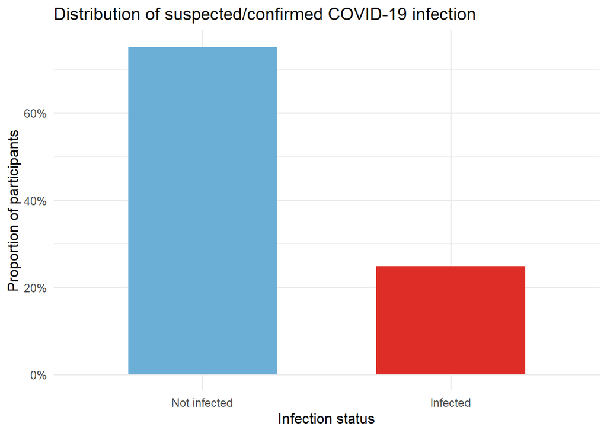

## 3.1 Logistic Regression and Chi-Square Analysis

*Figure 2. Proportion of infected versus non-infected participants by current DMT status. Infection prevalence was similar in those on and off DMT (≈25 %), indicating no apparent association.*

COVID-19 diagnosis by DMT status

| dmt_status | N | Infected | Percent |
| --- | --- | --- | --- |
| Not on DMT | 261 | 67 | 25.7 |
| On DMT | 880 | 216 | 24.5 |

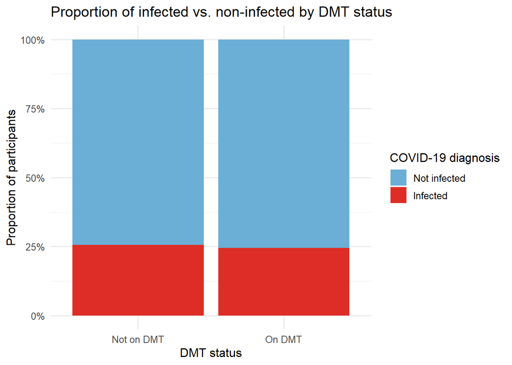

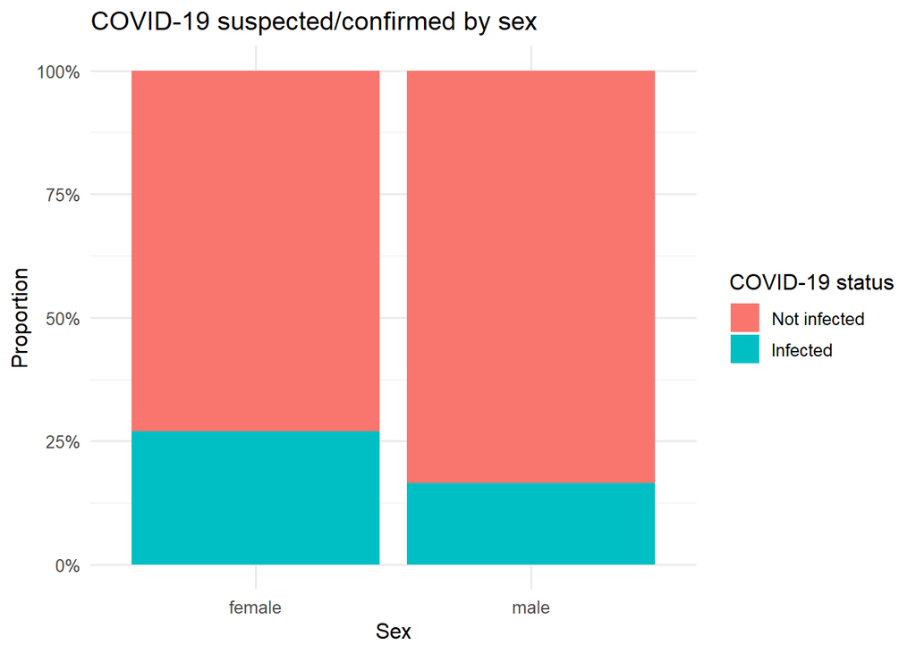

*Table 2. Logistic regression results showing the association between DMT status and COVID-19 infection. DMT use was not significantly associated with infection (aOR = 0.94, 95 % CI 0.68–1.30), whereas male sex was associated with lower odds of infection (aOR = 0.54, 95 % CI 0.37–0.78).*

Logistic regression: factors associated with COVID-19 diagnosis

| term | estimate | std.error | statistic | p.value | conf.low | conf.high |
| --- | --- | --- | --- | --- | --- | --- |
| (Intercept) | 0.37 | 0.16 | -6.07 | 0.00 | 0.27 | 0.51 |
| dmt_statusOn DMT | 0.94 | 0.16 | -0.41 | 0.68 | 0.68 | 1.30 |
| sexmale | 0.54 | 0.19 | -3.19 | 0.00 | 0.37 | 0.78 |
| age_group51-70 | 0.90 | 0.17 | -0.65 | 0.51 | 0.64 | 1.24 |
| has_comorbiditiesyes | 1.23 | 0.15 | 1.41 | 0.16 | 0.92 | 1.65 |

*Table 3. Chi-square test of independence showing no significant unadjusted association between DMT status and infection (χ² = 0.08, p = 0.77).*

```
##
##  Pearson's Chi-squared test with Yates' continuity correction
##
## data:  table(covid_ms$dmt_status, covid_ms$infected)
## X-squared = 0.082945, df = 1, p-value = 0.7733
```